# Chapter4

### Linear regression: crime vs. rad and tax

Simple regression sheds some light to the relationship between crime rate and two variables it is mosty significantly correlated. However, as the data is quite packed to the right the regular regression model is not particularly helpful.

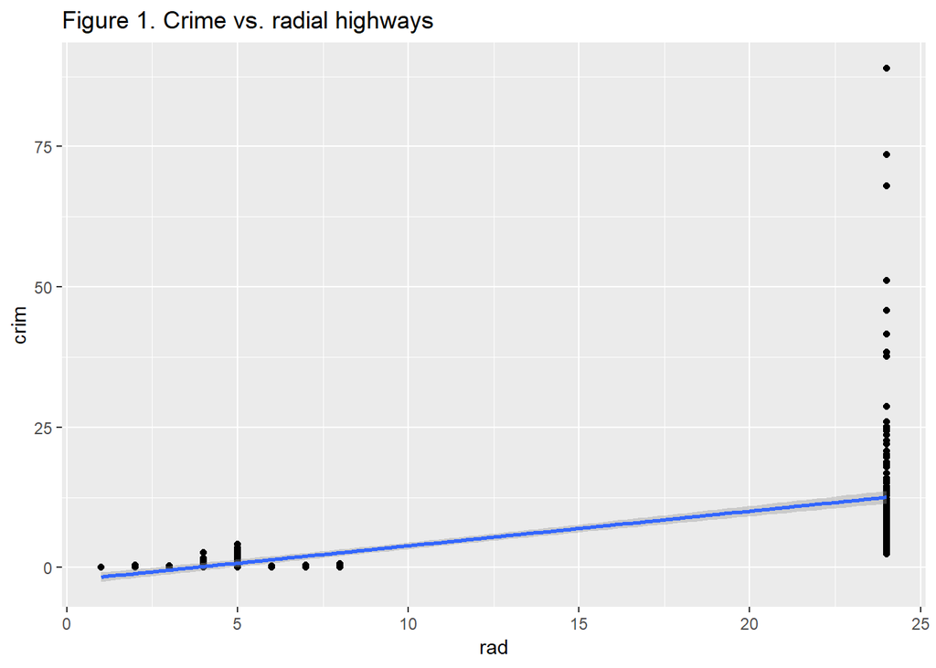

```r
p1 <- ggplot(Boston, aes(x = rad, y = crim))
p2 <- p1 + geom_point() + geom_smooth(method = "lm")
p3 <- p2 + ggtitle("Figure 1. Crime vs. radial highways")
p3
```

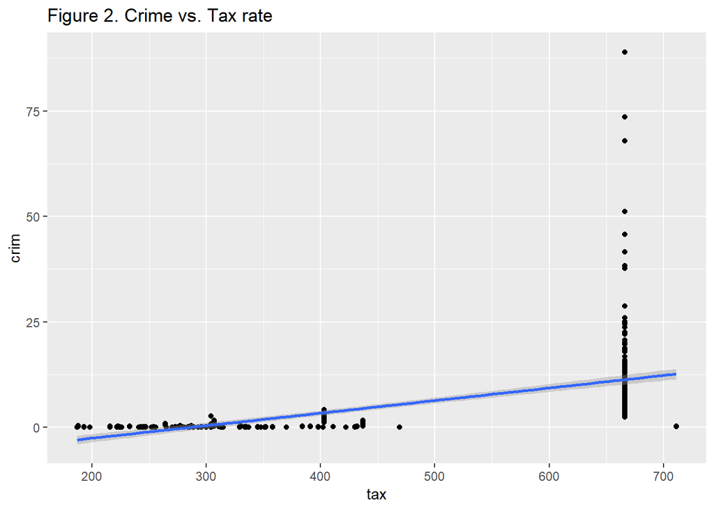

```r
p1 <- ggplot(Boston, aes(x = tax, y = crim))
p2 <- p1 + geom_point() + geom_smooth(method = "lm")
p3 <- p2 + ggtitle("Figure 2. Crime vs. Tax rate")
p3
```

## Part 2: Scale and classify the data set

Let’s scale the data to set the scene for the distance measurement and cluster analysis

```r
boston_scaled <-scale(Boston)
kable(summary(boston_scaled), caption = " Summary of Scaled Boston data set")
```

Summary of Scaled Boston data set

[output not shown]

### Categorized crime rate

Lets then create a categorical variable of the crime rate in the Boston dataset (from the scaled crime rate). And lets also kill the old crime rate variable from the dataset.

```r
boston_scaled<-as.data.frame(boston_scaled)

bins <- quantile(boston_scaled$crim)
label<-c("low", "med_low", "med_high", "high")
crime <- cut(boston_scaled$crim, breaks = bins, include.lowest = TRUE, label = label)
table(crime)
```

```
## crime
##      low  med_low med_high     high
##      127      126      126      127
```

```r
boston_scaled <- dplyr::select(boston_scaled, -crim)
boston_scaled <- data.frame(boston_scaled, crime)
```

### Train and test set

Now, divide the dataset to train and test sets, so that we have 80% of the data in the train set

```r
n <- nrow(boston_scaled)
ind <- sample(n,  size = n * 0.8)
train <- boston_scaled[ind,]
test <- boston_scaled[-ind,]
correct_classes <- test$crime
```

## Part 3: Linear disriminant analysis

Let’s then fit the linear discriminant analysis on the train set. Categorical crime rate is the target variable and all the other variables in the dataset as predictor variables.

```r
lda.fit <- lda(crime ~., data = train)
lda.arrows <- function(x, myscale = 1, arrow_heads = 0.1, color = "red", tex = 0.75, choices = c(1,2)){
  heads <- coef(x)
  arrows(x0 = 0, y0 = 0,
         x1 = myscale * heads[,choices[1]],
         y1 = myscale * heads[,choices[2]], col=color, length = arrow_heads)
  text(myscale * heads[,choices], labels = row.names(heads),
       cex = tex, col=color, pos=3)
}
classes <- as.numeric(train$crime)
lda.fit
```

```
## Call:
## lda(crime ~ ., data = train)
##
## Prior probabilities of groups:
##       low   med_low  med_high      high
## 0.2227723 0.2623762 0.2450495 0.2698020
##
## Group means:
##                   zn      indus        chas        nox          rm
## low       0.88482818 -0.8664602 -0.09734683 -0.8312075  0.55160284
## med_low  -0.07667138 -0.3490916 -0.01233188 -0.5995894 -0.08813739
## med_high -0.37290116  0.1130621  0.04582045  0.3551454  0.03245004
## high     -0.48724019  1.0169738 -0.05560795  1.0416900 -0.44662830
##                 age        dis        rad        tax     ptratio
## low      -0.8327714  0.7845385 -0.6960305 -0.7415013 -0.46651430
## med_low  -0.3648861  0.3937303 -0.5452370 -0.4900179 -0.08665764
## med_high  0.3827719 -0.3216292 -0.4354793 -0.3512986 -0.15955717
## high      0.8064386 -0.8651132  1.6395837  1.5150965  0.78247128
##                black       lstat        medv
## low       0.37898166 -0.77006244  0.62126733
## med_low   0.32019229 -0.17464068  0.02166651
## med_high  0.08225217  0.06302537  0.06880973
## high     -0.77787161  0.91843322 -0.68846550
##
## Coefficients of linear discriminants:
##                  LD1         LD2         LD3
## zn       0.107096482  0.66689647 -1.11982633
## indus    0.057992059 -0.16582739  0.21707315
## chas    -0.106114662  0.01904120  0.21626154
## nox      0.331219809 -0.96688630 -1.37883500
## rm      -0.093721354 -0.04009692 -0.14689826
## age      0.241808198 -0.30517693  0.01574223
## dis     -0.064477703 -0.29280637  0.30659855
## rad      3.424907341  0.92741664 -0.18846255
## tax      0.001204362  0.07032294  0.80826950
## ptratio  0.116880201 -0.06623922 -0.46633133
## black   -0.101282210  0.05386673  0.11900641
## lstat    0.204583020 -0.19091135  0.27508303
## medv     0.167549106 -0.38007066 -0.24066539
##
## Proportion of trace:
##    LD1    LD2    LD3
## 0.9603 0.0277 0.0121
```

And now a nice visualisation of the LDA: color by the group + arrows for directions and weights of the different explanatory variables.

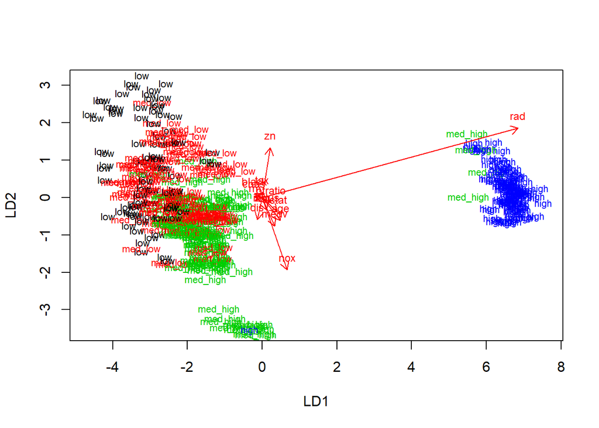

```r
plot(lda.fit, dimen = 2, col = classes, pch = classes)
lda.arrows(lda.fit, myscale = 2)
```

Based on the visualisation, it looks the variable rad has major impact to the classification.

Next, test how well the LDA model works: First, kill the crime data from the test set. And then let’s predict the classes with the LDA model on the test data.

```r
test <- boston_scaled[-ind,]
correct_classes <- test$crime
test <- dplyr::select(test, -crime)

lda.pred <- predict(lda.fit, newdata = test)
table(correct = correct_classes, predicted = lda.pred$class)
```

```
##           predicted
## correct    low med_low med_high high
##   low       22      14        1    0
##   med_low    1      16        3    0
##   med_high   0       7       18    2
##   high       0       0        0   18
```